# CDSS-8 Peer-graded Assignment: Prediction Assignment Writeup

Ram Kishore Pasupathi

5 September 2018

## Introduction to the project

Using devices such as Jawbone Up, Nike FuelBand, and Fitbit it is now possible to collect a large amount of data about personal activity relatively inexpensively. These type of devices are part of the quantified self movement - a group of enthusiasts who take measurements about themselves regularly to improve their health, to find patterns in their behavior, or because they are tech geeks. One thing that people regularly do is quantify how much of a particular activity they do, but they rarely quantify how well they do it. In this project, your goal will be to use data from accelerometers on the belt, forearm, arm, and dumbell of 6 participants. They were asked to perform barbell lifts correctly and incorrectly in 5 different ways. More information is available from the website here: http://groupware.les.inf.puc-rio.br/har (see the section on the Weight Lifting Exercise Dataset).

### Data

The training data for this project are available here:

https://d396qusza40orc.cloudfront.net/predmachlearn/pml-training.csv

The test data are available here:

https://d396qusza40orc.cloudfront.net/predmachlearn/pml-testing.csv

The data for this project come from this source: http://groupware.les.inf.puc-rio.br/har. If you use the document you create for this class for any purpose please cite them as they have been very generous in allowing their data to be used for this kind of assignment.

## Analysis

### Summary

1. Load the data set and briefly learn the characteristics of the data
2. Choosing covariants by,
   - removing variables with near zero variance
   - removing variables with high correlation (as PCA returned model with less accuracy)
   - removing variables with high percentage (>95%) of NA values
3. Partioning data into test, train and validate datasets
4. Building Decision tree
5. Building Random Forest
6. Prediction on Validation datasets
7. Calculating accuracy & deciding the best classification model
8. Classification based on the test dataset

### Loading Datasets

```r
data_train=read.csv(url("https://d396qusza40orc.cloudfront.net/predmachlearn/pml-training.csv"))
data_test=read.csv(url("https://d396qusza40orc.cloudfront.net/predmachlearn/pml-testing.csv"))
dim(data_train)
```

```
## [1] 19622   160
```

As we observed that the dataset contains a massive range of variables, choosing the right coviant becomes ideal. Hence, we use nearZeroVar() function from caret package as the function removes variables with near zero variables.

```r
library(caret)
nrv=nearZeroVar(data_train)
refine_train=data_train[,-nrv]
dim(refine_train)
```

```
## [1] 19622   100
```

Through nearZeroVar() approach we were able to reduce the variables to 100

### Removing variables with NA values

Significant varaibles have 97% of NA values. Retaining those variables within the dataset would yield no productive result, hence, dropping from the dataset.

```r
na_col=as.data.frame(colSums(is.na(refine_train)))
na_df=as.data.frame(cbind("col"=rownames(na_col),"nas"=round(as.numeric(na_col[,1]/nrow(refine_train)),2)))
nas=na_df[na_df$nas!=0,]
refine_train=refine_train[,!(names(refine_train) %in% nas[,1])]
dim(refine_train)
```

```
## [1] 19622    59
```

### Removing inappropriate variables

```r
refine_train=refine_train[,-c(1,2,3,4,5)]
dim(refine_train)
```

```
## [1] 19622    54
```

### Multicolinearity Inspection

A correllogram to identify multicolinearity

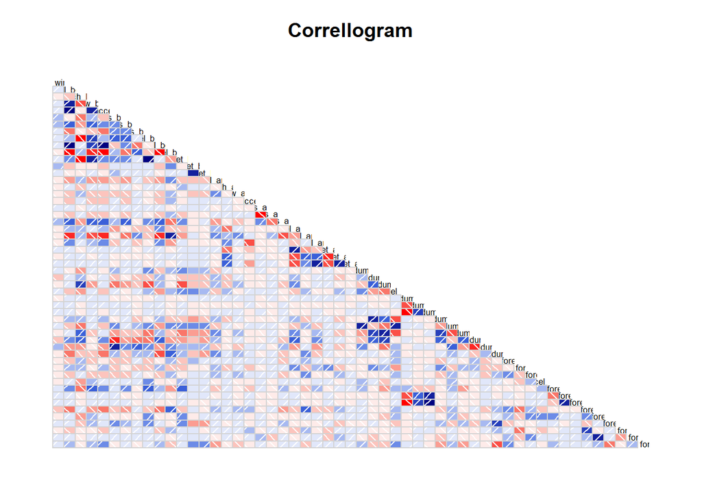

```r
for_cor=refine_train
library(corrgram)
corrgram(for_cor[,!(names(for_cor) %in% "classe")], order=NULL, lower.panel=panel.shade,upper.panel=NULL, text.panel=panel.txt,main="Correllogram")
```

### Removing highly correlated variables

Further trimming by dropping the highly correlated variables in the dataset. 80% has been considered threshold where variables with more than 80% association has been dropped. NOte: An iteration of model creation along with PCA transformation was performed and due to the underformance of the transformed variables during model building process, the PCA componenets were dropped.

```r
refine_train2=refine_train
refine_train2=as.data.frame(sapply(refine_train[,!(names(refine_train) %in% "classe")],as.numeric))
m=abs(cor(refine_train2[,!((names(refine_train2)) %in% "classe")]))
m[upper.tri(m)]=0
diag(m)=0
uncor_data=refine_train2[,!apply(m,2,function(x) any(x>0.8))]
dim(uncor_data)
```

```
## [1] 19622    40
```

```r
uncor_data=data.frame(cbind(uncor_data,"classe"=refine_train$classe))
intrain=createDataPartition(y=uncor_data$classe,p=0.8,list=F)
training=uncor_data[intrain,]
validation=uncor_data[-intrain,]
```

### Decision Tree

```r
modelfit_dt=train(classe~.,data=training,method="rpart")
library(rattle)
```

[figure not shown]

```r
fancyRpartPlot(modelfit_dt$finalModel)
```

```r
confusionMatrix(modelfit_dt)
```

```
## Bootstrapped (25 reps) Confusion Matrix
##
## (entries are percentual average cell counts across resamples)
##
##           Reference
## Prediction    A    B    C    D    E
##          A 24.2  3.8  1.6  2.6  1.8
##          B  1.0  8.5  1.0  2.5  2.9
##          C  2.7  6.2 14.3  8.2  4.7
##          D  0.5  0.8  0.4  2.1  0.8
##          E  0.1  0.0  0.1  0.9  8.3
##
##  Accuracy (average) : 0.5742
```

Decision tree returns model with accuracy 57%

### Random Forest

```r
library(randomForest)
modelfit_rf=randomForest(classe~.,data=training)
modelfit_rf
```

```
##
## Call:
##  randomForest(formula = classe ~ ., data = training)
##                Type of random forest: classification
##                      Number of trees: 500
## No. of variables tried at each split: 6
##
##         OOB estimate of  error rate: 0.17%
## Confusion matrix:
##      A    B    C    D    E  class.error
## A 4464    0    0    0    0 0.0000000000
## B    2 3035    1    0    0 0.0009874918
## C    0   12 2726    0    0 0.0043827611
## D    0    0    9 2563    1 0.0038865138
## E    0    0    0    2 2884 0.0006930007
```

### Applying Random Forest model on Validation set

```r
pred_rf1=predict(modelfit_rf,validation)
cm=table(pred_rf1,validation$classe)
n=sum(cm)
diag=diag(cm)
accuracy=sum(diag)/n
accuracy
```

```
## [1] 0.9969411
```

### Refining Test set

```r
refine_test=data_test[,-nrv]
refine_test=refine_test[,-c(1,2,3,4,5)]
refine_test=refine_test[,!(names(refine_test) %in% nas[,1])]
refine_test=refine_test[,!(names(refine_test) %in% "problem_id")]
testing=refine_test[,!apply(m,2,function(x) any(x>0.8))]
dim(testing)
```

```
## [1] 20 40
```

### Applying Random Forest model on Test set

```r
final_pred=predict(modelfit_rf,testing)
```

## Conclusion

The prediction on test dataset is as follows,

```r
final_pred
```

```
##  1  2  3  4  5  6  7  8  9 10 11 12 13 14 15 16 17 18 19 20
##  B  A  B  A  A  E  D  B  A  A  B  C  B  A  E  E  A  B  B  B
## Levels: A B C D E
```

The model was able to classify varibales with less error rate